# Check August 2018 Data

Carmen

October 11, 2018

# Read in all data

```r
df <- read_excel("~/../Dropbox (Stephens Lab)/Shrub_experiment/Data/Compiled/Seedling_vert_Aug_2018_compiled.xlsx")
```

# Do some basic cleaning

## Remove columns used to check values in the field

```r
df <- df %>%
  select(-`DIA/ht check`, - `DIA/DIA CHECK`, -`GR/HT CHECK`)
```

## Rename columns

```r
df <- df %>%
  rename(SEEDLING = `seedling tag #`) %>%
  rename(leader_damage = `leader broke or died`) %>%
  rename(dead2017 = dead)
```

## Delete row with all NA’s

```r
npre <- nrow(df)
df %>% dplyr::filter((is.na(compartment) & is.na(plot)))
```

```
## # A tibble: 1 x 16
##   compartment island  plot SEEDLING species date2018 dead2017 dead2018
##         <dbl> <chr>  <dbl>    <dbl> <chr>   <chr>    <chr>    <chr>
## 1          NA <NA>      NA       NA <NA>    <NA>     <NA>     <NA>
## # ... with 8 more variables: ht_cm_2017 <dbl>, gr_2017_cm <dbl>,
## #   gr_2018_cm <chr>, bas_dia_mm_1 <chr>, bas_dia_mm_2 <chr>,
## #   leader_damage <chr>, notes_2017 <chr>, notes_2018 <chr>
```

```r
df <- df %>% filter(!(is.na(compartment) & is.na(plot)))
npost <- nrow(df)
```

This removed 1 rows, bringing the total to 456.

## Make numeric columns numeric

### gr_2018_cm

#### Look at non-numeric values at the head and tail of sorted values

```r
df %>%
  arrange(gr_2018_cm) %>%
  select(gr_2018_cm, notes_2017, notes_2018) %>%
  slice(1:10)
```

```
## # A tibble: 10 x 3
##    gr_2018_cm          notes_2017                  notes_2018
##    <chr>               <chr>                       <chr>
##  1 -                   <NA>                        <NA>
##  2 0.11                probably germinated in 2015 <NA>
##  3 0.28000000000000003 <NA>                        <NA>
##  4 0.36                <NA>                        <NA>
##  5 0.41                <NA>                        <NA>
##  6 0.42                2014 birth                  <NA>
##  7 0.42                <NA>                        top bent
##  8 0.45                <NA>                        <NA>
##  9 0.51                <NA>                        <NA>
## 10 0.54                <NA>                        <NA>
```

```r
df %>%
  arrange(gr_2018_cm) %>%
  mutate(gr_2018_cm = as.numeric(gr_2018_cm)) %>%
  select(gr_2018_cm, notes_2017, notes_2018) %>%
  slice(1:10)
```

```
## # A tibble: 10 x 3
##    gr_2018_cm notes_2017                  notes_2018
##         <dbl> <chr>                       <chr>
##  1      NA    <NA>                        <NA>
##  2       0.11 probably germinated in 2015 <NA>
##  3       0.28 <NA>                        <NA>
##  4       0.36 <NA>                        <NA>
##  5       0.41 <NA>                        <NA>
##  6       0.42 2014 birth                  <NA>
##  7       0.42 <NA>                        top bent
##  8       0.45 <NA>                        <NA>
##  9       0.51 <NA>                        <NA>
## 10       0.54 <NA>                        <NA>
```

```r
df %>%
  arrange(gr_2018_cm) %>%
  select(gr_2018_cm, notes_2017, notes_2018) %>%
  slice(415:440)
```

```
## # A tibble: 26 x 3
##    gr_2018_cm      notes_2017           notes_2018
##    <chr>           <chr>                <chr>
##  1 9.41            very curvy seedling  <NA>
##  2 9.449999999999~ <NA>                 partially girdled
##  3 9.61            same growth 2016 an~ <NA>
##  4 9.61            first stem           fork 2 cm above ground, measured ~
##  5 9.67            <NA>                 partially girdled
##  6 na              <NA>                 tip dead, bud not yet set
##  7 na              <NA>                 leader died bf bud set
##  8 na              <NA>                 last 3 yes growth dead
##  9 na              top died before don~ <NA>
## 10 na              <NA>                 leader dead
## # ... with 16 more rows
```

```r
df %>%
  arrange(gr_2018_cm) %>%
  mutate(gr_2018_cm = as.numeric(gr_2018_cm)) %>%
  select(gr_2018_cm, notes_2017, notes_2018) %>%
  slice(415:440)
```

```
## # A tibble: 26 x 3
##    gr_2018_cm notes_2017             notes_2018
##         <dbl> <chr>                  <chr>
##  1       9.41 very curvy seedling    <NA>
##  2       9.45 <NA>                   partially girdled
##  3       9.61 same growth 2016 and ~ <NA>
##  4       9.61 first stem             fork 2 cm above ground, measured dia~
##  5       9.67 <NA>                   partially girdled
##  6      NA    <NA>                   tip dead, bud not yet set
##  7      NA    <NA>                   leader died bf bud set
##  8      NA    <NA>                   last 3 yes growth dead
##  9      NA    top died before done ~ <NA>
## 10      NA    <NA>                   leader dead
## # ... with 16 more rows
```

What I learned from this: any non-numeric value (“-”, “na”, etc) will automatically be converted to NA if you apply is.numeric() to the column.

#### Change to numeric

```r
df <- df %>%
  mutate(gr_2018_cm = as.numeric(gr_2018_cm))
```

### bas_dia_mm_1 and bas_dia_mm_2

```r
df <- df %>%
  mutate(bas_dia_mm_1 = as.numeric(bas_dia_mm_1)) %>%
  mutate(bas_dia_mm_2 = as.numeric(bas_dia_mm_2))
```

## Replace NA’s with data for dead columns

### For some trees, NA was recorded for dead because the tree was thrown out. Might as well record it as alive.

```r
df %>% filter(is.na(dead2017))
```

```
## # A tibble: 8 x 16
##   compartment island  plot SEEDLING species date2018 dead2017 dead2018
##         <dbl> <chr>  <dbl>    <dbl> <chr>   <chr>    <chr>    <chr>
## 1         180 E          1       35 CADE    <NA>     <NA>     <NA>
## 2         180 E          1       37 CADE    <NA>     <NA>     <NA>
## 3         380 K          2       34 CADE    <NA>     <NA>     <NA>
## 4         380 K          2       36 PSME    <NA>     <NA>     <NA>
## 5         380 K          2       38 CADE    <NA>     <NA>     <NA>
## 6         380 K          2       39 PSME    <NA>     <NA>     <NA>
## 7         380 K          2       40 CADE    <NA>     <NA>     <NA>
## 8         380 L          2       34 ABCO    <NA>     <NA>     <NA>
## # ... with 8 more variables: ht_cm_2017 <dbl>, gr_2017_cm <dbl>,
## #   gr_2018_cm <dbl>, bas_dia_mm_1 <dbl>, bas_dia_mm_2 <dbl>,
## #   leader_damage <chr>, notes_2017 <chr>, notes_2018 <chr>
```

```r
df <- df %>% mutate(dead2017 = ifelse(is.na(dead2017), "A", dead2017))
```

### Default to 2017 dead status if nothing is recorded for dead2018

```r
df <- df %>%
  mutate(dead2018 = ifelse(is.na(dead2018), dead2017, dead2018))
```

## Move info in notes to appropriate columns where possible

### Dead in notes column

```r
df <- df %>%
  mutate(dead2018 = ifelse(!is.na(df$notes_2018) & notes_2018 == "dead", "D", dead2018))%>%
  mutate(notes_2018 = ifelse(!is.na(df$notes_2018) & notes_2018 == "dead", NA, notes_2018))
```

#### Check

```r
summary(as.factor(df$dead2018))
```

```
##   A   D
## 432  24
```

### Leader damage

```r
df <- df %>%
  mutate(leader_damage = ifelse(notes_2018 %in% grep("leader dead|leader died|tip dead|last 3 yes growth dead", df$notes_2018, value = T),
                                paste(leader_damage, "2018"), leader_damage))
```

# See if all compartments and islands and plots are represented

```r
print(df %>% group_by(compartment, island, plot) %>%
  summarise(count = n()), n = 50)
```

```
## # A tibble: 48 x 4
## # Groups:   compartment, island [?]
##    compartment island  plot count
##          <dbl> <chr>  <dbl> <int>
##  1         180 A          1     4
##  2         180 A          2     6
##  3         180 B          1    16
##  4         180 B          2    14
##  5         180 C          1    14
##  6         180 C          2     6
##  7         180 D          1    16
##  8         180 D          2     8
##  9         180 E          1    10
## 10         180 E          2     3
## 11         180 F          1     6
```

[output cut: 37 more lines]

# Compare to previous seedling list from 2017

## Full but edited df

Note: there are three sets of 2017 df’s, because some seedlings had vert data but not diameter data and vice versa. I’m using the most complete option, but it still has some seedlings thrown out for reasons like death.

```r
df18 <- df
remove(df)
load("~/../Dropbox (Stephens Lab)/Shrub_experiment/Data/JOINED_DATA/df.Rdata")
df17 <- df
remove(df)
```

### Rename column name in 2017 data

```r
df17 <- df17 %>%
  rename(SEEDLING = sdlg)
```

### Compare counts

```r
nrow(df17)
```

```
## [1] 433
```

```r
nrow(df18)
```

```
## [1] 456
```

```r
nrow(df18)-nrow(df17)
```

```
## [1] 23
```

There are 23 more seedlings in the 2018 data than the 2017 data. The reasons for deletion from 2017 data are detailed in `README_shrub_experiment`. However, to make sure that there aren’t missing seedlings cancelling each other out, I’ll have to bring in a *complete* data set from 2017.

## Full and unedited df

```r
load("~/../Dropbox (Stephens Lab)/Shrub_experiment/Data/JOINED_DATA/df_unedited.Rdata")
df17_ue <- df
remove(df)
```

#### Rename column

```r
df17_ue <- df17_ue %>% rename(SEEDLING = sdlg)
```

#### Use anti_join to look for differences

```r
nrow(df17_ue)
```

```
## [1] 456
```

```r
anti_join(df18, df17_ue, by = c("compartment", "island", "plot", "SEEDLING"))
```

```
## # A tibble: 0 x 16
## # ... with 16 variables: compartment <dbl>, island <chr>, plot <dbl>,
## #   SEEDLING <dbl>, species <chr>, date2018 <chr>, dead2017 <chr>,
## #   dead2018 <chr>, ht_cm_2017 <dbl>, gr_2017_cm <dbl>, gr_2018_cm <dbl>,
## #   bas_dia_mm_1 <dbl>, bas_dia_mm_2 <dbl>, leader_damage <chr>,
## #   notes_2017 <chr>, notes_2018 <chr>
```

```r
anti_join(df17_ue, df18, by = c("compartment", "island", "plot", "SEEDLING"))
```

```
## # A tibble: 0 x 18
## # ... with 18 variables: compartment <dbl>, island <chr>, plot <dbl>,
## #   SEEDLING <dbl>, spring_dia_1_mm <dbl>, spring_dia_2_mm <dbl>,
## #   notes.spring <chr>, growing <chr>, species <chr>, dead <chr>,
## #   ht_cm <dbl>, gr_2017_cm <dbl>, gr_2016_cm <dbl>, gr_2015_cm <dbl>,
## #   Aug_dia_1_mm <dbl>, Aug_dia_2_mm <dbl>, leader_damage <chr>,
## #   notes.Aug <chr>
```

All good!

# Create a column for whether the seedling was thrown out in 2017 or 2018 for indesputable reasons

```r
df18 <- df18 %>%
  mutate(thrown_out = ifelse(species %in% c("PSME", "CADE")
                             | notes_2017 %in% grep("thrown out", df18$notes_2017, value = T)
                             | notes_2017 %in% grep("Dropped from study", df18$notes_2017, value = T)
                             | notes_2017 %in% grep("excluding from study", df18$notes_2017, value = T)
                             | notes_2017 %in% grep("too broken to measure", df18$notes_2017, value = T),
                             1, 0))
```

# Check for errors or missing fields in the 2018 data

```r
repeats <- df18 %>%
  group_by(compartment, island, plot, SEEDLING) %>%
  summarise(n = n()) %>%
  filter(n > 1)
```

## Repeat seedlings

```r
for(i in 1:nrow(repeats)){
  print(df18 %>%
    filter(compartment == repeats$compartment[i] & island == repeats$island[i] & plot == repeats$plot[i] & SEEDLING == repeats$SEEDLING[i]) %>%
    select(compartment, island, plot, SEEDLING, notes_2017, notes_2018)
  )
}
```

```
## # A tibble: 2 x 6
##   compartment island  plot SEEDLING notes_2017  notes_2018
##         <dbl> <chr>  <dbl>    <dbl> <chr>       <chr>
## 1         180 G          2      118 first stem  <NA>
## 2         180 G          2      118 second stem <NA>
## # A tibble: 2 x 6
##   compartment island  plot SEEDLING notes_2017  notes_2018
##         <dbl> <chr>  <dbl>    <dbl> <chr>       <chr>
## 1         180 J          1       20 first stem  fork 2 cm above ground, m~
## 2         180 J          1       20 second stem fork 2 cm above ground, m~
```

The only repeats are legitimate and due to forking at the base.

## Missing data - look for NA’s in any field

```r
summary(as.factor(df18$compartment))
```

```
## 180 380 570
## 273 112  71
```

```r
summary(as.factor(df18$island))
```

```
##  A  B  C  D  E  F  G  H  J  K  L  N  O  P  Q  R  S  U
## 10 30 31 24 20 19 37 21 53 18 20 38 14 35 43 24  8 11
```

```r
summary(as.factor(df18$plot))
```

```
##   1   2
## 237 219
```

```r
summary(df18$SEEDLING)
```

```
##    Min. 1st Qu.  Median    Mean 3rd Qu.    Max.
##    1.00   15.00   30.50   42.61   43.25  130.00
```

```r
summary(as.factor(df18$species))
```

```
## ABCO CADE PIPO PSME
##  263    5  186    2
```

```r
summary(as.factor(df18$dead))
```

```
## integer(0)
```

```r
summary(as.factor(df18$dead2018))
```

```
##   A   D
## 432  24
```

```r
summary(df18$ht_cm_2017)
```

```
##    Min. 1st Qu.  Median    Mean 3rd Qu.    Max.    NA's
##    6.00   20.00   42.00   49.51   70.00  203.00      11
```

```r
summary(df18$gr_2017_cm)
```

```
##    Min. 1st Qu.  Median    Mean 3rd Qu.    Max.    NA's
##   0.000   1.800   3.600   4.657   6.600  27.500      11
```

```r
summary(df18$gr_2018_cm)
```

```
##    Min. 1st Qu.  Median    Mean 3rd Qu.    Max.    NA's
##   0.110   2.263   3.690   4.918   6.647  24.500      38
```

### Check why some seedlings have NA in some fields

#### ht_cm_2017

```r
df18 %>% filter(is.na(ht_cm_2017) & thrown_out == 0) %>% select(species, notes_2017, notes_2018)
```

```
## # A tibble: 0 x 3
## # ... with 3 variables: species <chr>, notes_2017 <chr>, notes_2018 <chr>
```

They were all thrown out.

#### gr_2017_cm

```r
df18 %>% filter(is.na(gr_2017_cm) & thrown_out == 0) %>% select(species, notes_2017, notes_2018)
```

```
## # A tibble: 0 x 3
## # ... with 3 variables: species <chr>, notes_2017 <chr>, notes_2018 <chr>
```

They were all thrown out.

#### gr_2018_cm

```r
df18 %>%
  filter(is.na(gr_2018_cm)
         & dead2018 != "D"
         & !leader_damage %in% grep("2018", df18$leader_damage, value = T)
         & thrown_out == 0) %>%
  select(compartment, island, SEEDLING, species, notes_2017, notes_2018, leader_damage, dead2018)
```

```
## # A tibble: 1 x 8
##   compartment island SEEDLING species notes_2017 notes_2018 leader_damage
##         <dbl> <chr>     <dbl> <chr>   <chr>      <chr>      <chr>
## 1         180 P            23 PIPO    previous ~ bad leade~ 0
## # ... with 1 more variable: dead2018 <chr>
```

#### bas_dia_mm_1 and bas_dia_mm_1

```r
df18 %>%
  filter((is.na(bas_dia_mm_1) | is.na(bas_dia_mm_2) )
         & dead2018 != "D"
         & thrown_out == 0) %>%
  select(compartment, island, SEEDLING, species, notes_2017, notes_2018, bas_dia_mm_1, bas_dia_mm_2, dead2018)
```

```
## # A tibble: 1 x 9
##   compartment island SEEDLING species notes_2017 notes_2018 bas_dia_mm_1
##         <dbl> <chr>     <dbl> <chr>   <chr>      <chr>             <dbl>
## 1         180 P            23 PIPO    previous ~ bad leade~           NA
## # ... with 2 more variables: bas_dia_mm_2 <dbl>, dead2018 <chr>
```

## Check for negative values

```r
df18 %>%
  filter_all(any_vars(.<0))
```

```
## # A tibble: 0 x 17
## # ... with 17 variables: compartment <dbl>, island <chr>, plot <dbl>,
## #   SEEDLING <dbl>, species <chr>, date2018 <chr>, dead2017 <chr>,
## #   dead2018 <chr>, ht_cm_2017 <dbl>, gr_2017_cm <dbl>, gr_2018_cm <dbl>,
## #   bas_dia_mm_1 <dbl>, bas_dia_mm_2 <dbl>, leader_damage <chr>,
## #   notes_2017 <chr>, notes_2018 <chr>, thrown_out <dbl>
```

## Check for outliers or strange combinations of values

### Make compartment, seedling, plot and thrown_out factors

```r
df18 <- df18 %>%
  mutate(compartment = as.factor(compartment)) %>%
  mutate(plot = as.factor(plot)) %>%
  mutate(thrown_out = as.factor(thrown_out)) %>%
  mutate(SEEDLING = as.factor(SEEDLING))
```

### Plot histograms of each variable to look for outliers

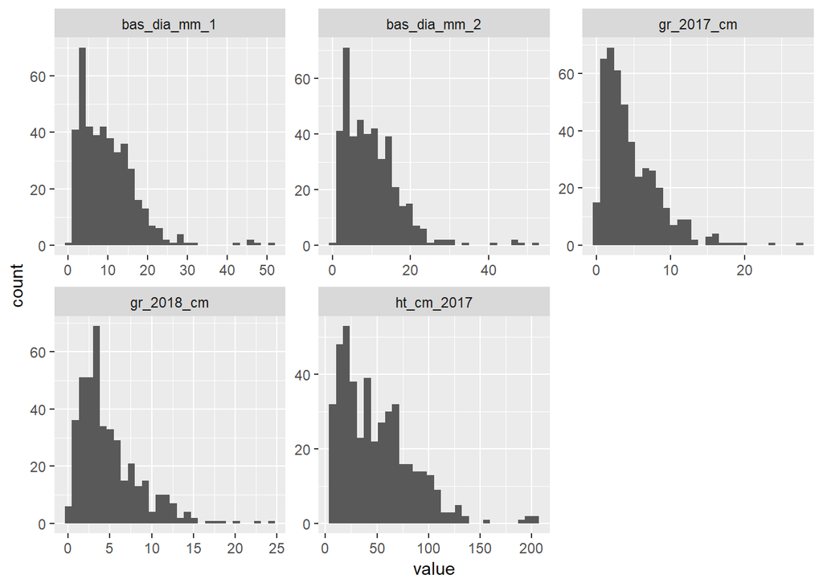

```r
df18 %>%
  keep(is.numeric) %>%
  gather() %>%
  ggplot(aes(value))+
  facet_wrap(~key, scales = "free")+
  geom_histogram()
```

### Plot ratios of dia to height, dia to dia, and growth to height

#### dia-ht

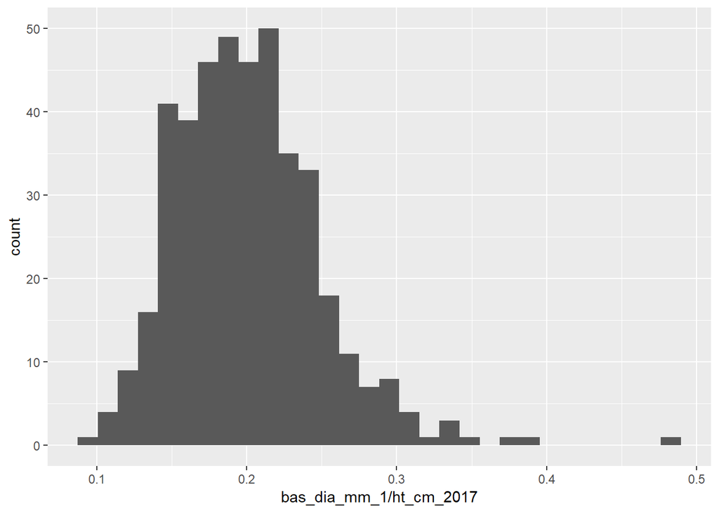

```r
ggplot(df18) +
  geom_histogram(aes(bas_dia_mm_1/ht_cm_2017))
```

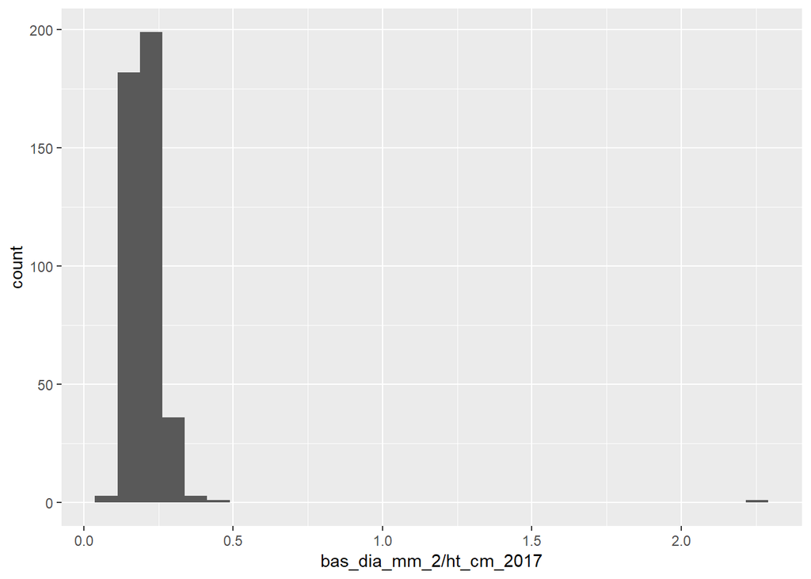

```r
ggplot(df18) +
  geom_histogram(aes(bas_dia_mm_2/ht_cm_2017))
```

Clearly there is an error with the seedling with a very high dia to height ratio for one measurement.

##### Look at the seedling with outlier dia-ht for dia 2

```r
df18 %>%
  filter(bas_dia_mm_1/bas_dia_mm_2<.5)
```

```
## # A tibble: 1 x 17
##   compartment island plot  SEEDLING species date2018 dead2017 dead2018
##   <fct>       <chr>  <fct> <fct>    <chr>   <chr>    <chr>    <chr>
## 1 570         O      2     36       ABCO    <NA>     A        A
## # ... with 9 more variables: ht_cm_2017 <dbl>, gr_2017_cm <dbl>,
## #   gr_2018_cm <dbl>, bas_dia_mm_1 <dbl>, bas_dia_mm_2 <dbl>,
## #   leader_damage <chr>, notes_2017 <chr>, notes_2018 <chr>,
## #   thrown_out <fct>
```

#### dia-dia

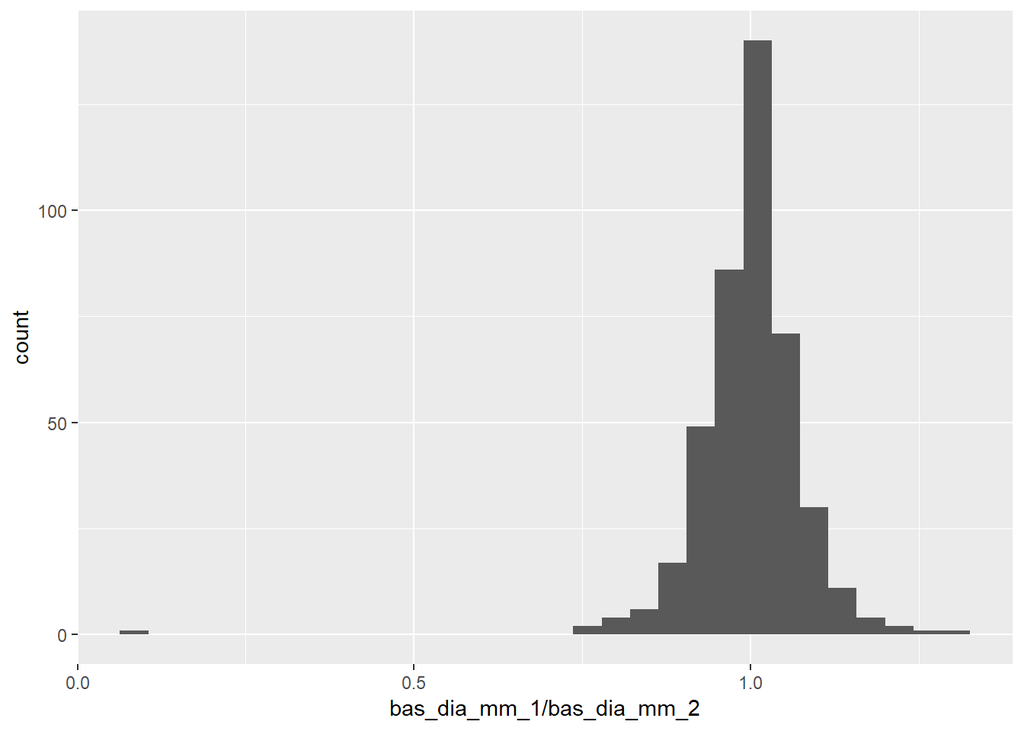

```r
ggplot(df18) +
  geom_histogram(aes(bas_dia_mm_1/bas_dia_mm_2))
```

##### Look at the seedling with outlier dia-dia

```r
df18 %>%
  filter(bas_dia_mm_1/bas_dia_mm_2<.5)
```

```
## # A tibble: 1 x 17
##   compartment island plot  SEEDLING species date2018 dead2017 dead2018
##   <fct>       <chr>  <fct> <fct>    <chr>   <chr>    <chr>    <chr>
## 1 570         O      2     36       ABCO    <NA>     A        A
## # ... with 9 more variables: ht_cm_2017 <dbl>, gr_2017_cm <dbl>,
## #   gr_2018_cm <dbl>, bas_dia_mm_1 <dbl>, bas_dia_mm_2 <dbl>,
## #   leader_damage <chr>, notes_2017 <chr>, notes_2018 <chr>,
## #   thrown_out <fct>
```

#### The combination of the above histograms shows that bas_dia_mm_2 for seedling 570-O-2-36 is actually 2.5, not 25, so correct that.

```r
df18 <- df18 %>%
  mutate(bas_dia_mm_2 = ifelse(
    compartment == "570" & island == "O" & plot == "2" & SEEDLING == "36",
    2.5,
    bas_dia_mm_2
  ))
```

#### growth-height

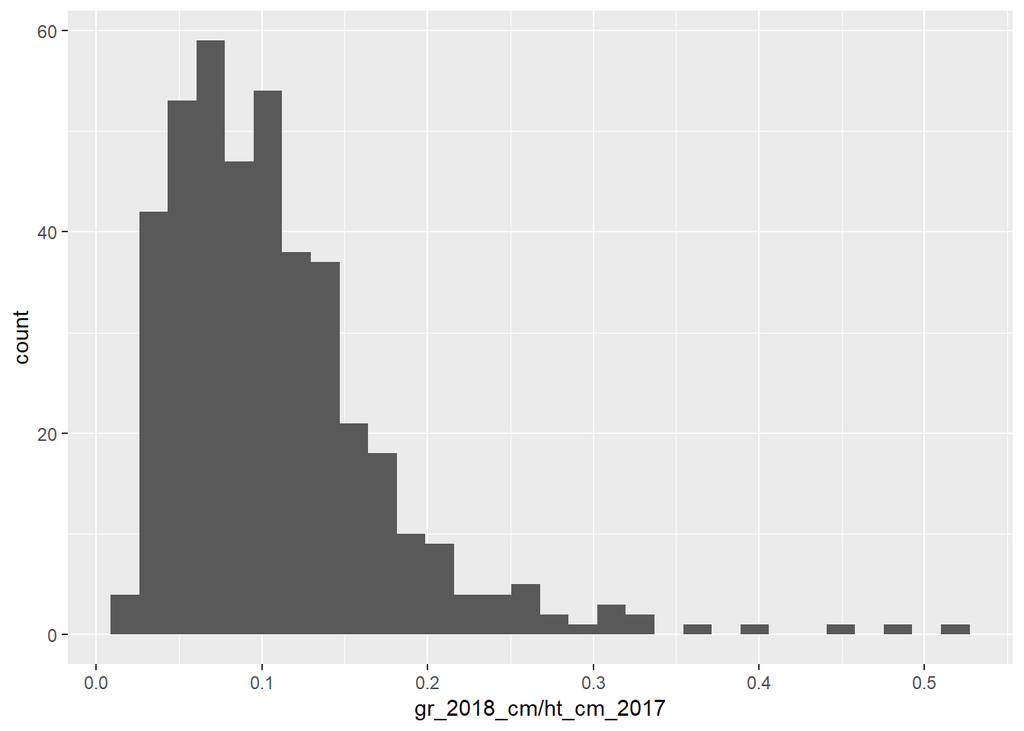

```r
ggplot(df18) +
  geom_histogram(aes(gr_2018_cm/ht_cm_2017))
```

##### Look at outlier

```r
df18 %>%
  filter(gr_2018_cm/ht_cm_2017>.75)
```

```
## # A tibble: 0 x 17
## # ... with 17 variables: compartment <fct>, island <chr>, plot <fct>,
## #   SEEDLING <fct>, species <chr>, date2018 <chr>, dead2017 <chr>,
## #   dead2018 <chr>, ht_cm_2017 <dbl>, gr_2017_cm <dbl>, gr_2018_cm <dbl>,
## #   bas_dia_mm_1 <dbl>, bas_dia_mm_2 <dbl>, leader_damage <chr>,
## #   notes_2017 <chr>, notes_2018 <chr>, thrown_out <fct>
```

### Check for big differences between 2017 growth and 2018 growth

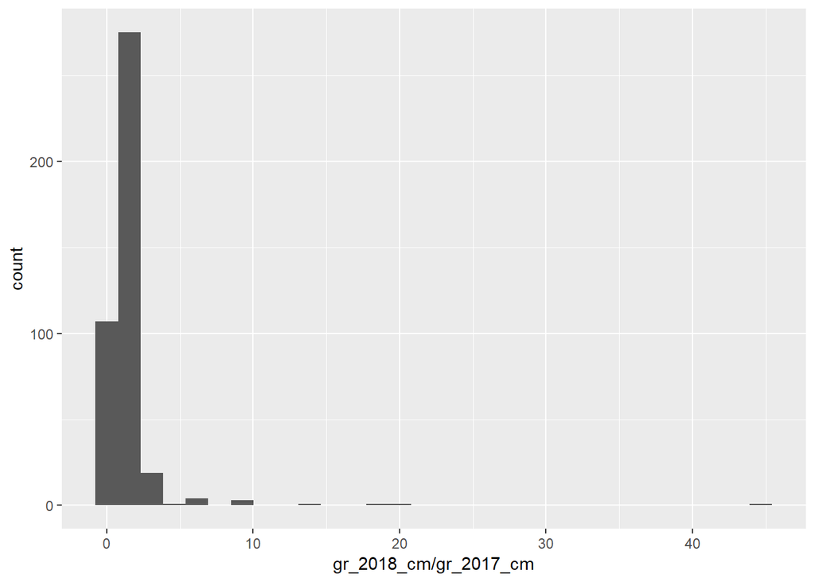

```r
ggplot(df18) +
  geom_histogram(aes(gr_2018_cm/gr_2017_cm))
```

##### Look at outlier

```r
df18 %>%
  filter(gr_2018_cm/gr_2017_cm > 40) %>%
  select(compartment, island, plot, SEEDLING, ht_cm_2017, gr_2017_cm, gr_2018_cm, notes_2017, notes_2018)
```

```
## # A tibble: 6 x 9
##   compartment island plot  SEEDLING ht_cm_2017 gr_2017_cm gr_2018_cm
##   <fct>       <chr>  <fct> <fct>         <dbl>      <dbl>      <dbl>
## 1 570         J      1     105              57        0.3      13.5
## 2 380         K      1     7                 9        0         4.09
## 3 180         P      2     11               14        0         3.64
## 4 180         Q      1     7                 6        0         0.11
## 5 570         J      2     114              53        0        10.3
## 6 180         R      2     7                 6        0         0.62
## # ... with 2 more variables: notes_2017 <chr>, notes_2018 <chr>
```

I think this is just because the leader was damaged in 2017, and the growth that year was very small. The growth in 2018 is not crazy relative to height.

# Save edited data frame

```r
save(df18, file = "~/../Dropbox (Stephens Lab)/Shrub_experiment/Data/JOINED_DATA/df2018.Rdata")
write.csv(df18, file = "~/../Dropbox (Stephens Lab)/Shrub_experiment/Data/JOINED_DATA/compiled_cleaned_Aug2018.csv", row.names = F)
```